# SS3 to opal: eastern Pacific bigeye tuna

Bridging the IATTC SAC-14 exploratory model, a quarterly Stock Synthesis model with growth cessation, to opal

Author

Nicholas Ducharme-Barth

Published

October 30, 2026

**Setup: read the caches**

```r
# Code is shown (folded) in the HTML version and hidden in the PDF.
knitr::opts_chunk$set(echo = knitr::is_html_output())
library(data.table)
library(ggplot2)
library(patchwork)

bridge = readRDS(file.path("data", "epo-bet-ss3-bridge-cache.rds"))
opal_c = readRDS(file.path("data", "epo-bet-opal-cache.rds"))

theme_set(theme_bw(base_size = 11) +
          theme(legend.position = "bottom", panel.grid.minor = element_blank()))
fmt = function(x, d = 2) ifelse(is.na(x), "", formatC(x, format = "f", digits = d, big.mark = ","))
sci = function(x, d = 1) formatC(x, format = "e", digits = d)
pct = function(x, d = 0) paste0(fmt(100 * x, d), "%")

B = bridge$summary
S = opal_c$summary
G = opal_c$growth_fit
TM = opal_c$timing
qtr_to_year = function(q) 1975 + (q - 17) / 4
model_col = c("SS3 B1" = "grey20", O0 = "#7D3C98", O1 = "#2471A3", O2 = "#C0392B",
              `O1-noComp` = "#CA6F1E")
fleets = opal_c$fleets
```

# 1 Overview

This document bridges an exploratory Stock Synthesis (SS3, Methot and Wetzel 2013) assessment model of bigeye tuna (*Thunnus obesus*) in the eastern Pacific Ocean (EPO), prepared by IATTC staff for the 14th meeting of the IATTC Scientific Advisory Committee (SAC-14, IATTC 2023), to opal. Any model runs here are preliminary explorations and should not be used *as is* for management advice.

The baseline SS3 model is itself a simplification. The models in the IATTC’s risk analysis for EPO bigeye have two sexes and time-varying selectivity; the model used here has one sex and time-invariant selectivity, so that its structure is close to what opal can represent. Its results are not those of the risk-analysis models, and differences between SS3 and opal found here say nothing about how opal would compare with them.

- **The model is quarterly.** Each SS3 “year” is a quarter (17-204, taken as 1975 Q1 to 2021 Q4) and ages are quarters (0-40). opal takes the same layout: 188 time steps of one season and 41 ages.
- **One SS3 bridge step.** The supplied model (B0) estimates a regime offset on the initial equilibrium recruitment, which opal does not have; B1 removes it (Section 3). Growth needs no step: SS3’s growth cessation model (Maunder et al. 2018) and its SD-linear growth variability are both in opal, and the conversion reproduces SS3’s length-at-age and SD-at-age exactly below the plus group (Section 4.2).
- **The inputs reconcile; the dynamics differ.** The converted inputs reconcile with SS3 within the tolerances of Table 3, and opal at SS3’s parameter values matches an independent replay of the converted inputs, so the gap between opal and SS3 lies in the dynamics. opal removes each quarter’s catch at the start of the quarter, as a harvest rate, while SS3 removes it through the quarter. With M of 0.48 per quarter at age 0 and large purse-seine catches of young fish, that leaves far more fish alive in opal (Section 4.4). Catch timing is the largest difference between the two models for this stock.
- **opal fits** (Section 5) estimate the scale and recruitment with SS3’s selectivity held fixed (O1) and with opal’s own double normals (O2).

# 2 The model

```r
knitr::kable(fleets[, .(`opal fishery` = fishery, `SS3 fleet` = ss3_fleet, name,
                        `catch units` = units, compositions = comps,
                        `variance adjustment` = fmt(var_adjust, 2))], format = "pipe")
```

Table 1: Fisheries and data in opal (SS3 fleet numbers are kept). Units: catch in weight (1) or numbers (2). Compositions: the variance adjustment is opal’s divisor of the input sample size, the inverse of SS3’s multiplier.

| opal fishery | SS3 fleet | name | catch units | compositions | variance adjustment |
| --- | --- | --- | --- | --- | --- |
| 1 | 1 | LL-n-A1 | 2 | none | 1.00 |
| 2 | 2 | LL-n-A2 | 2 | size (10 cm) | 1.25 |
| 3 | 3 | LL-n-A3 | 2 | size (10 cm) | 1.69 |
| 4 | 4 | LL-n-A4 | 2 | size (10 cm) | 2.50 |
| 5 | 5 | LL-n-A5 | 2 | size (10 cm) | 2.50 |
| 6 | 6 | LL-n-A6 | 2 | size (10 cm) | 3.23 |
| 7 | 7 | LL-n-A7 | 2 | size (10 cm) | 2.40 |
| 8 | 8 | LL-w-A1 | 1 | none | 1.00 |
| 9 | 9 | LL-w-A2 | 1 | none | 1.00 |
| 10 | 10 | LL-w-A3 | 1 | none | 1.00 |
| 11 | 11 | LL-w-A4 | 1 | none | 1.00 |
| 12 | 12 | LL-w-A5 | 1 | none | 1.00 |
| 13 | 13 | LL-w-A6 | 1 | none | 1.00 |
| 14 | 14 | LL-w-A7 | 1 | none | 1.00 |
| 15 | 15 | OBJ-A1 | 1 | length (2 cm) | 4.13 |
| 16 | 16 | OBJ-A2 | 1 | length (2 cm) | 8.33 |
| 17 | 17 | OBJ-A3 | 1 | length (2 cm) | 35.71 |
| 18 | 18 | OBJ-A4 | 1 | length (2 cm) | 8.33 |
| 19 | 19 | OBJ-A5 | 1 | length (2 cm) | 37.88 |
| 20 | 20 | OBJ-Disc | 1 | none | 1.00 |
| 21 | 21 | NOA-A1 | 1 | none | 1.00 |
| 22 | 22 | NOA-A2 | 1 | none | 1.00 |
| 23 | 23 | LL-Survey | 2 | size (10 cm) | 1.25 |

- **Fisheries.** Longline fisheries in seven areas, with catch in numbers (LL-n) and in weight (LL-w; their selectivity mirrors the LL-n fishery of the same area); floating-object purse seine in five areas (OBJ) and its discards (OBJ-Disc, age-based selectivity of 1 at ages 1-3 quarters); unassociated purse seine in two areas (NOA, mirroring OBJ-A1 and OBJ-A5).
- **Index.** One longline index (LL-Survey, numbers, lognormal), with its own double-normal selectivity and SS3’s floating catchability.
- **Compositions.** OBJ length compositions on 2 cm bins (20-198 cm); the longline fisheries’ and the index’s compositions are SS3 generalised size compositions on 10 cm bins (60-190 cm). In opal they are two composition bin schemes predicted from the same 2 cm population grid. SS3 gives zero weight to the NOA length compositions, LL-n-A1’s size compositions and a handful of conditional age-at-length records, which are left out.
- **Biology.** Age-specific M (0.48 per quarter at age 0, falling to 0.10 at age 13 and rising to 0.14 from age 26), growth cessation, length-based maturity, spawning output proportional to weight (Nsexes = -1, female fraction 0.5), Beverton-Holt recruitment with steepness 1 and sigma<sub>R</sub> 0.6.

# 3 The SS3 bridge

```r
knitr::kable(B[, .(step = label, `n par` = n_par, NLL = fmt(nll, 2), survey = fmt(nll_survey, 2),
                   length = fmt(nll_length, 2), `size freq.` = fmt(nll_sizefreq, 2),
                   recruitment = fmt(nll_recruit, 2), `ln R0` = fmt(ln_r0, 3),
                   `regime offset` = fmt(regime, 3), `SSB0` = fmt(ssb0, 0),
                   depletion = fmt(depletion, 3), `F/Fmsy` = fmt(f_end, 2),
                   `max gradient` = sci(max_gradient, 1))], format = "pipe")
```

Table 2: The SS3 bridge. Negative log-likelihoods; SSB in tonnes; depletion and F/F<sub>MSY</sub> in the last quarter (2021 Q4).

| step | n par | NLL | survey | length | size freq. | recruitment | ln R0 | regime offset | SSB0 | depletion | F/Fmsy | max gradient |
| --- | --- | --- | --- | --- | --- | --- | --- | --- | --- | --- | --- | --- |
| B0 SAC-14 model | 264 | 271.20 | -261.19 | 220.85 | 327.10 | -15.58 | 9.449 | -0.409 | 371,192 | 0.221 | -1.57 | 1.8e-03 |
| B1 no regime offset | 263 | 274.60 | -261.35 | 220.60 | 329.12 | -13.79 | 9.457 | 0.000 | 374,298 | 0.249 | -1.65 | 2.0e-02 |

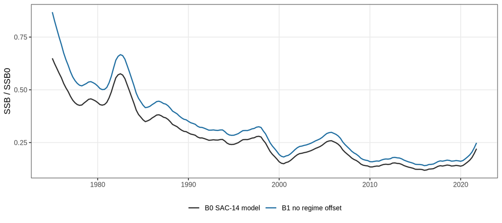

Figure 1: Spawning biomass relative to unfished in the two SS3 bridge models.

```r
ggplot(bridge$timeseries[era == "TIME"], aes(year, depletion, colour = label)) +
    geom_line(linewidth = 0.7) +
    scale_colour_manual(values = c("grey20", "#2471A3")) +
    labs(x = NULL, y = "SSB / SSB0", colour = NULL)
```

The supplied files were run with an SS3 3.30.22 beta build. Re-run with SS3 3.30.22.1 from the supplied parameters, B0 reproduces the supplied likelihood exactly (271.196) and re-estimation stays there.

```r
tsw = dcast(bridge$timeseries[era == "TIME"], quarter + year ~ step, value.var = "ssb")
setnames(tsw, c("quarter", "year", "b0", "b1"))
tsw[, rel := b1 / b0 - 1]
mid = tsw[year >= 1980 & year < 2011, range(rel)]
```

B0 starts the population from an equilibrium whose recruitment is 34% below the stock-recruitment curve (a regime offset of -0.41 on ln R<sub>0</sub> for block year 16, the quarter before the model starts). The model begins in 1975 although longline fishing on the stock goes back decades (the data file carries catches for 1971-1974 that SS3 ignores, and the initial F is fixed at almost 0), and the offset is what lets the 1975 population start below its unfished level: it scales every initial age class by exp(-0.41). SS3’s lambda on the regime penalty is 0, so the offset is informed by the data alone; SS3 estimates it at -0.41 (SE 0.16).

B1 removes it. The initial equilibrium recruitment is then tied to the unfished stock-recruitment relationship, while the 24 penalised early recruitment deviations can still alter the initial age structure; they take over part of the offset’s job (their mean is -0.24 in B1 against 0.00 in B0). The likelihood worsens by 3.4 units, and the difference does not wash out: B1’s spawning biomass is 35% above B0’s in 1975 Q1, 16% to 23% above it from 1980 to 2010, and 14% above it in 2021 Q4 (depletion 0.249 against 0.221). opal is converted from B1, so the comparison in the rest of this document is with a model whose trajectory differs from the supplied one by this much (Section 6).

# 4 Converting B1 to opal

`config/epo-bet-b1.yaml` records the choices the SS3 files do not determine. The opal model has:

- 188 quarterly time steps, one season each, ages 0-40 quarters;
- 23 fisheries: SS3’s 22 fishing fleets in SS3 order and one fishery for the index;
- SS3’s age-basis biology (M, maturity, and spawning output) from the endgrowth table at the start of the quarter, and SS3’s *mid*-quarter weight-at-age, which opal uses to turn catch in weight into numbers (Section 4.4);
- SS3’s parameter values: B<sub>0</sub> (opal’s scale parameter, SS3’s SSB<sub>0</sub>), h, sigma<sub>R</sub>, the main and late recruitment deviations, the 24 early deviations and the first quarter’s recruitment as the initial age structure, the initial F of LL-n-A2 and OBJ-A5, and SS3’s growth.

## 4.1 Reconciliation

```r
R = copy(opal_c$recon)[!is.na(pass)]
R[, group := ifelse(grepl("^catch total", quantity), "catch totals, 22 fishing fleets", quantity)]
knitr::kable(R[, .(n = .N, `max relative difference` = sci(max(rel_diff, na.rm = TRUE), 1),
                   pass = all(pass)), by = .(Quantity = group)], format = "pipe")
```

Table 3: Reconciliation with SS3 (exact comparisons). The 22 catch totals are summarised in one row.

| Quantity | n | max relative difference | pass |
| --- | --- | --- | --- |
| catch totals, 22 fishing fleets | 22 | 0.0e+00 | TRUE |
| CPUE observation count (kept SS3 index fleets) | 1 | 0.0e+00 | TRUE |
| LF total input sample size | 1 | 0.0e+00 | TRUE |
| LF observation rows | 1 | 0.0e+00 | TRUE |
| unfished spawning potential per recruit | 1 | 1.8e-06 | TRUE |
| total weight summed over ages (Wt_Mid) | 1 | 0.0e+00 | TRUE |
| mean length-at-age, SS3 growth cessation (max relative error below the plus group) | 1 | 4.5e-06 | TRUE |
| SD of length-at-age, SS3 CV_Growth_Pattern 2 (max relative error below the plus group) | 1 | 9.6e-07 | TRUE |

## 4.2 Growth

SS3’s growth cessation model (GrowthModel 8) is Eq. 2 of Maunder et al. (2018), which opal implements as `growth_model = "cessation"`. The parameters map directly:

| SS3 | Value | opal |
| --- | --- | --- |
| L at age 0 (AFIX = 0) | 22.79 cm | `L0` |
| rmax (labelled VonBert_K) | 10.2127 cm per quarter | `rmax` |
| Cessation | 0.1811 | `k_gc` |
| Linf (Growth_Age_for_L2 = 999) | 191.628 cm | `t50` = 16.248 quarters, as SS3 computes it from Linf |
| SS3 age 0 = opal position 1 |  | `age_offset` = -1 |

SS3’s CV_Growth_Pattern 2 makes the SD of length-at-age linear in mean length, from 3.53 cm at L<sub>0</sub> to 9.48 cm at Linf; opal’s `growth_sd_model = "sd"` does the same. Linf is not a modelled length, so opal’s upper reference is the mean length at the oldest age, with the SD SS3’s line takes there (9.453 cm).

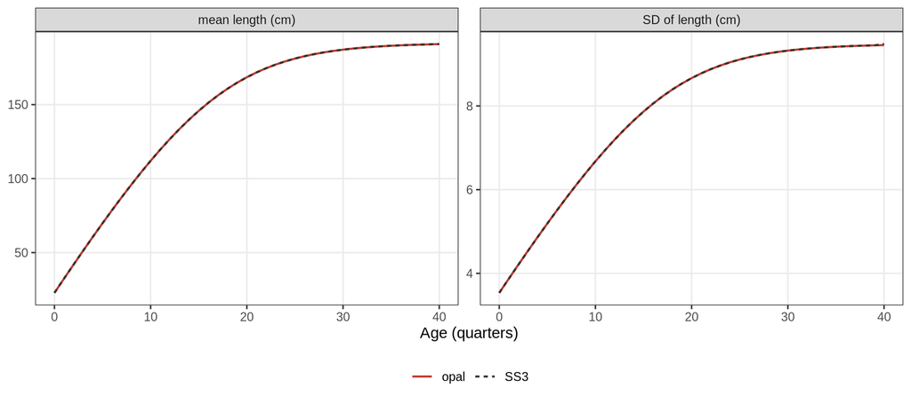

Figure 2: Mean and SD of length-at-age: SS3 (Report.sso, start of the quarter) and opal.

```r
gd = data.table(age = 0:40, ss3_mean = G$laa_ss3, opal_mean = G$laa_opal,
                ss3_sd = G$sd_ss3, opal_sd = G$sd_opal)
gl = rbind(gd[, .(age, what = "mean length (cm)", model = "SS3", value = ss3_mean)],
           gd[, .(age, what = "mean length (cm)", model = "opal", value = opal_mean)],
           gd[, .(age, what = "SD of length (cm)", model = "SS3", value = ss3_sd)],
           gd[, .(age, what = "SD of length (cm)", model = "opal", value = opal_sd)])
ggplot(gl, aes(age, value, colour = model, linetype = model)) + geom_line(linewidth = 0.7) +
    facet_wrap(~what, scales = "free_y") +
    scale_colour_manual(values = c(SS3 = "grey20", opal = "#C0392B")) +
    labs(x = "Age (quarters)", y = NULL, colour = NULL, linetype = NULL)
```

Below the plus group opal’s length-at-age matches SS3’s to 4.5e-06 and its SD to 9.6e-07 (relative), the precision of Report.sso. At the plus group SS3 averages length over the ages it accumulates (190.96 cm against opal’s 190.87 cm) and holds the SD at SD_old itself.

## 4.3 Selectivity

SS3’s selectivity is size-based, like opal’s, so its double normals carry over rather than being fitted. Two details are converted:

- SS3 places the end of the plateau relative to the midpoint of its last *population* length bin (221 cm), opal relative to its last data length bin (199 cm). opal’s top parameter is re-solved so the plateau ends where SS3’s does.
- Where SS3 sets a start or end parameter to -999 (no rescaling of that limb), opal’s end value is set to the value SS3’s unscaled limb takes at the first or last bin.

OBJ-Disc’s selectivity is on age in SS3 (1 at ages 1-3 quarters, 0 elsewhere); in opal it is an age-based double normal fitted to that and held fixed.

```r
sc = copy(opal_c$seed_check)
knitr::kable(sc[, .(`opal fishery` = fishery, name, `parameters from` = ifelse(is.na(source), "age-based fit", as.character(source)),
                    `max |diff|` = sci(max_abs_diff, 1))], format = "pipe")
```

Table 4: Largest difference between opal’s starting selectivity and SS3’s: at length for the length-based fisheries (mirrors take their source fleet’s parameters), at age for OBJ-Disc.

| opal fishery | name | parameters from | max \|diff\| |
| --- | --- | --- | --- |
| 1 | LL-n-A1 | 1 | 1.3e-05 |
| 2 | LL-n-A2 | 2 | 9.4e-06 |
| 3 | LL-n-A3 | 3 | 1.6e-06 |
| 4 | LL-n-A4 | 4 | 5.8e-05 |
| 5 | LL-n-A5 | 5 | 5.2e-06 |
| 6 | LL-n-A6 | 6 | 3.0e-06 |
| 7 | LL-n-A7 | 7 | 4.5e-06 |
| 8 | LL-w-A1 | 1 | 1.3e-05 |
| 9 | LL-w-A2 | 2 | 9.4e-06 |
| 10 | LL-w-A3 | 3 | 1.6e-06 |
| 11 | LL-w-A4 | 4 | 5.8e-05 |
| 12 | LL-w-A5 | 5 | 5.2e-06 |
| 13 | LL-w-A6 | 6 | 3.0e-06 |
| 14 | LL-w-A7 | 7 | 4.5e-06 |
| 15 | OBJ-A1 | 15 | 2.7e-06 |
| 16 | OBJ-A2 | 16 | 1.4e-05 |
| 17 | OBJ-A3 | 17 | 2.6e-06 |
| 18 | OBJ-A4 | 18 | 4.6e-04 |
| 19 | OBJ-A5 | 19 | 3.0e-06 |
| 20 | OBJ-Disc | age-based fit | 1.4e-03 |
| 21 | NOA-A1 | 15 | 2.7e-06 |
| 22 | NOA-A2 | 19 | 3.0e-06 |
| 23 | LL-Survey | 23 | 1.0e-05 |

Every fleet’s SS3 age selectivity (pattern 10) is 0 at age 0. opal applies its length curves to every age through the PLA, so the OBJ fisheries select some age-0 fish in opal that SS3 does not; at the start of the quarter an age-0 fish is 22.8 cm. SS3 also evaluates fishery selectivity on the mid-quarter size distribution, opal at the start of the quarter. Both show in opal’s starting selectivity-at-age:

```r
knitr::kable(opal_c$sel_start_diff[, .(fishery, name, `max |diff|` = fmt(max_abs_diff, 3),
                                        `opal at age 0` = fmt(age0_opal, 3))], format = "pipe")
```

Table 5: Largest difference between opal’s starting selectivity-at-age (O2 before fitting) and SS3’s, and opal’s selectivity at age 0, by fishery.

| fishery | name | max \|diff\| | opal at age 0 |
| --- | --- | --- | --- |
| 1 | LL-n-A1 | 0.117 | 0.000 |
| 2 | LL-n-A2 | 0.073 | 0.000 |
| 3 | LL-n-A3 | 0.133 | 0.000 |
| 4 | LL-n-A4 | 0.120 | 0.000 |
| 5 | LL-n-A5 | 0.088 | 0.000 |
| 6 | LL-n-A6 | 0.080 | 0.000 |
| 7 | LL-n-A7 | 0.121 | 0.000 |
| 8 | LL-w-A1 | 0.117 | 0.000 |
| 9 | LL-w-A2 | 0.073 | 0.000 |
| 10 | LL-w-A3 | 0.133 | 0.000 |
| 11 | LL-w-A4 | 0.120 | 0.000 |
| 12 | LL-w-A5 | 0.088 | 0.000 |
| 13 | LL-w-A6 | 0.080 | 0.000 |
| 14 | LL-w-A7 | 0.121 | 0.000 |
| 15 | OBJ-A1 | 0.322 | 0.020 |
| 16 | OBJ-A2 | 0.280 | 0.013 |
| 17 | OBJ-A3 | 0.237 | 0.026 |
| 18 | OBJ-A4 | 0.264 | 0.004 |
| 19 | OBJ-A5 | 0.140 | 0.010 |
| 20 | OBJ-Disc | 0.001 | 0.001 |
| 21 | NOA-A1 | 0.322 | 0.020 |
| 22 | NOA-A2 | 0.140 | 0.010 |
| 23 | LL-Survey | 0.084 | 0.000 |

## 4.4 opal at SS3’s values

O0 runs opal at SS3’s parameter values with SS3’s own selectivity-at-age. Nothing is estimated, so any difference from SS3 comes from the two models’ dynamics.

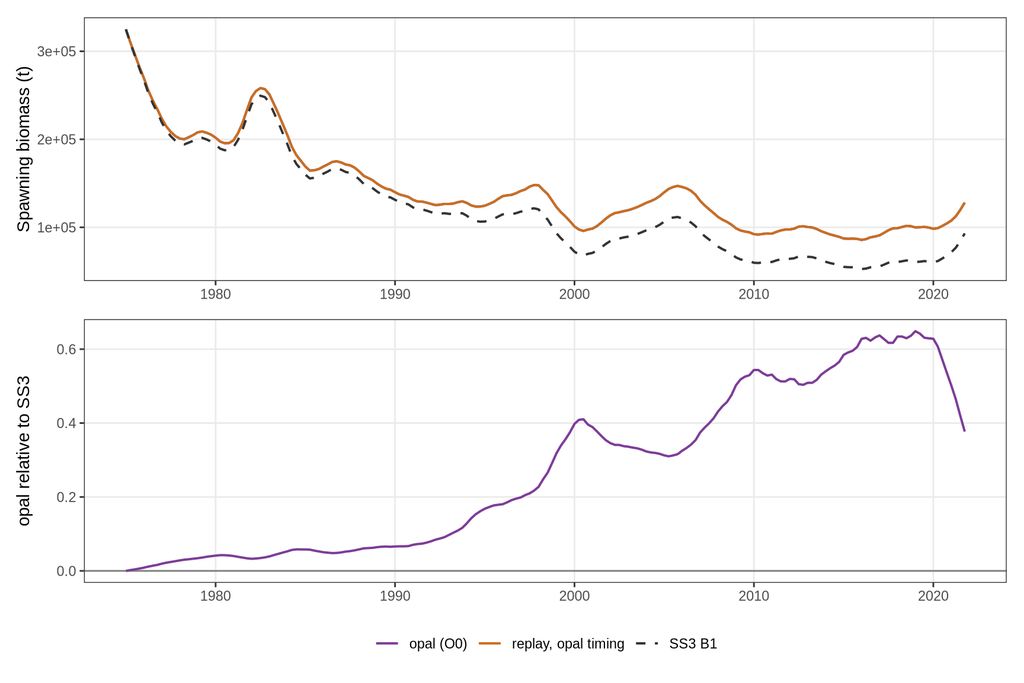

Figure 3: O0: opal at SS3’s values against SS3 B1 (top: spawning biomass; bottom: relative to SS3). ‘Replay’ replays the converted inputs outside opal with opal’s timing, which opal matches exactly.

```r
br = copy(opal_c$bridge)
br[, year := qtr_to_year(16 + ts)]
bl = rbind(br[, .(year, series = "SS3 B1", value = ss3)],
           br[, .(year, series = "opal (O0)", value = opal)],
           br[, .(year, series = "replay, opal timing", value = replica_opal)])
o0_col = c("SS3 B1" = "grey20", "opal (O0)" = "#7D3C98", "replay, opal timing" = "#CA6F1E")
p1 = ggplot(bl, aes(year, value, colour = series, linetype = series)) + geom_line(linewidth = 0.7) +
    scale_colour_manual(values = o0_col) +
    scale_linetype_manual(values = c("solid", "solid", "dashed")) +
    labs(x = NULL, y = "Spawning biomass (t)", colour = NULL, linetype = NULL)
p2 = ggplot(br, aes(year, rel_opal)) + geom_hline(yintercept = 0, colour = "grey50") +
    geom_line(linewidth = 0.7, colour = "#7D3C98") +
    labs(x = NULL, y = "opal relative to SS3")
(p1 / p2) + plot_layout(guides = "collect") & theme(legend.position = "bottom")
```

```r
bar  = TM[grepl("Baranov", removal)]
pope = TM[grepl("Pope", removal)]
```

The first quarter agrees to 0.00%: the initial age structure is converted directly. opal then drifts above SS3, to 38% by 2021 Q4. opal’s spawning biomass matches the replay of the converted inputs to 3e-07 (relative), which checks that opal uses the converted inputs as intended; the difference from SS3 is in the dynamics. Two things account for it: when the catch is taken within the quarter, and the weight at which catch in weight is turned into numbers.

```r
tt = TM[, .(`2001-2021 mean` = pct(mean(rel[qtr_to_year(16 + ts) >= 2001]), 1),
            `2021 Q4` = pct(rel[.N], 1),
            `largest |diff|` = pct(max(abs(rel)), 2)), by = .(removal, weight)]
knitr::kable(tt, format = "pipe")
```

Table 6: Spawning biomass relative to SS3 at SS3’s parameter values, by when the catch is removed and the weight used to turn catch in weight into numbers. Each replay starts from opal’s initial numbers-at-age (O0) and uses SS3’s selectivity-at-age and recruitment, so the replays differ from each other only in the catch step.

| removal | weight | 2001-2021 mean | 2021 Q4 | largest \|diff\| |
| --- | --- | --- | --- | --- |
| start of quarter | start-of-quarter | -46.1% | -62.2% | 84.80% |
| start of quarter | mid-quarter (opal here) | 48.4% | 37.7% | 64.87% |
| start of quarter | SS3 fleet catch weight | 43.1% | 33.9% | 58.04% |
| mid-quarter (Pope) | SS3 fleet catch weight | -3.6% | -4.8% | 7.55% |
| through the quarter (Baranov, SS3) | SS3 fleet catch weight | 0.0% | 0.0% | 0.00% |

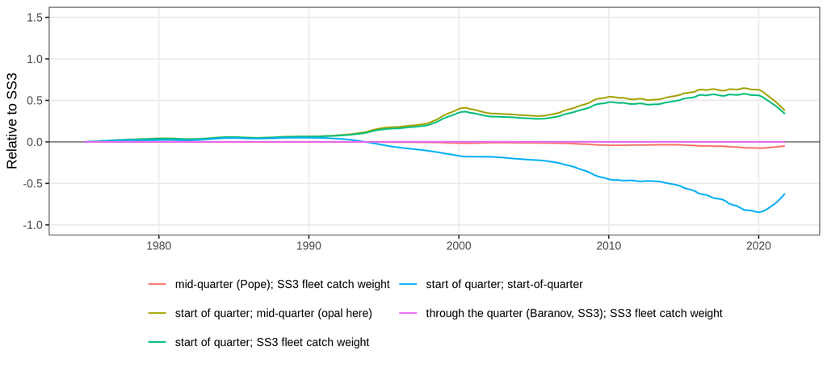

Figure 4: The replays of Table 6 relative to SS3.

```r
TM[, year := qtr_to_year(16 + ts)]
TM[, variant := paste0(removal, "; ", weight)]
ggplot(TM[ssb > 0], aes(year, rel, colour = variant)) + geom_hline(yintercept = 0, colour = "grey50") +
    geom_line(linewidth = 0.6) + coord_cartesian(ylim = c(-1, 1.5)) +
    labs(x = NULL, y = "Relative to SS3", colour = NULL) +
    guides(colour = guide_legend(ncol = 2))
```

- **Catch weight.** SS3 turns catch in weight into numbers with each fleet’s catch weight-at-age, which follows the fish’s growth through the quarter and the fleet’s selection within an age. Bigeye grow fast: an age-0 fish weighs 71% more at mid-quarter than at the start. opal has one weight-at-age vector. At the start-of-quarter weight it removes so many young fish for the same tonnage that the population collapses at SS3’s parameters; the mid-quarter weight (used here) and SS3’s fleet catch weights give similar results.
- **Catch timing.** opal removes each quarter’s catch at the start of the quarter, before natural mortality. SS3 removes it through the quarter (hybrid F), so part of the catch is fish that would otherwise have died. For the same catch opal leaves more fish alive, and with M of 0.48 per quarter at age 0 and the OBJ fisheries catching mostly fish under a year old, the difference accumulates. Removing the catch at mid-quarter (Pope’s approximation) brings the replay to within 8% of SS3 over the series; SS3’s catch equation with SS3’s fleet catch weights reproduces SS3 to 1e-05 (relative; the largest difference in any quarter).

# 5 opal fits

Growth, h, sigma<sub>R</sub>, M, the biology and the initial F stay at SS3’s values, as they are fixed in SS3 (except SD_young, held at SS3’s estimate); opal’s default priors are switched off, as SS3 has no parameter priors. Both fits estimate B<sub>0</sub>, the survey catchability, the main and late recruitment deviations and the initial age structure; the last deviation, which belongs to the quarter after the model, is fixed at 0.

- **O1** holds SS3’s selectivity-at-age.
- **O2** estimates opal’s own length-based double normals, started at SS3’s curves, for the parameters SS3 estimates (the peak, top and widths of LL-n-A2 to A7, OBJ-A1 to A5 and the index); mirrors share their source’s parameters. It starts from O1’s estimates.
- **O1-noComp** is O1 with the compositions switched off (lambda 0), so the index and the recruitment and initial-deviation penalties inform it.

```r
fit_tab = copy(S)
fit_tab[, comp := ifelse(is.na(lp_lf), "", ifelse(lp_lf_in_objective %in% FALSE,
                                                   paste0(fmt(lp_lf, 1), " (not in objective)"), fmt(lp_lf, 1)))]
knitr::kable(fit_tab[, .(model, `n par` = n_par, objective = fmt(objective, 2),
                   `max gradient` = ifelse(is.na(max_gradient), "", sci(max_gradient, 1)),
                   `Hessian PD` = ifelse(is.na(positive_hessian), "", as.character(positive_hessian)),
                   `B0 (t)` = fmt(B0, 0), `SSB 2021 Q4 (t)` = fmt(ssb_end, 0),
                   depletion = fmt(depletion_end, 3),
                   CPUE = fmt(lp_cpue, 1), compositions = comp,
                   recruitment = fmt(lp_rec, 1), unreported = fmt(unreported, 1))], format = "pipe")
```

Table 7: Fits. The objective values are opal’s and are not comparable with SS3’s likelihood (different constants, and opal’s compositions are predicted differently). Depletion is SSB / SSB0 in 2021 Q4. CPUE, compositions and recruitment are the negative log-likelihood terms opal reports (O1-noComp’s composition term is reported but not in its objective, lambda 0); the objective also contains the initial-deviation penalty, and ‘unreported’ is the objective minus the sum of every weighted term opal reports (see Section 6).

| model | n par | objective | max gradient | Hessian PD | B0 (t) | SSB 2021 Q4 (t) | depletion | CPUE | compositions | recruitment | unreported |
| --- | --- | --- | --- | --- | --- | --- | --- | --- | --- | --- | --- |
| SS3 B1 | 263 |  |  |  | 374,298 | 93,051 | 0.249 |  |  |  |  |
| O0 | 0 | 6,520.79 |  |  | 374,298 | 128,126 | 0.342 | 32.4 | 4,043.3 | 107.9 | 2,318.1 |
| O1 | 214 | 6,369.85 | 1.9e-11 | TRUE | 427,626 | 142,580 | 0.333 | -88.9 | 4,032.6 | 106.7 | 2,302.4 |
| O2 | 262 | 6,169.84 | 5.4e-02 | FALSE | 451,116 | 159,711 | 0.354 | -95.5 | 3,753.2 | 103.8 | 2,391.3 |
| O1-noComp | 214 | -6.54 | 3.6e-09 | TRUE | 382,806 | 113,803 | 0.297 | -127.9 | 4,210.0 (not in objective) | 103.8 | -0.0 |

```r
o0 = S[model == "O0"]; o1 = S[model == "O1"]; o2 = S[model == "O2"]
nc = S[model == "O1-noComp"]; ss = S[model == "SS3 B1"]
conv = function(x) if (isTRUE(x$check_passes)) "converges and passes opal's fit check" else
    sprintf("does not converge (maximum gradient %s)", sci(x$max_gradient, 1))
```

O1 converges and passes opal’s fit check. With SS3’s selectivity fixed, opal’s own optimum puts B<sub>0</sub> at 427,626 t (14% above SS3’s) and the 2021 Q4 depletion at 0.333, against SS3’s 0.249. That is close to where opal already sits at SS3’s values (O0, 0.342): re-estimating the scale and recruitment does not undo the catch-timing difference of Section 4.4, because in opal’s dynamics the same catches deplete the stock less. Without the compositions (O1-noComp), the index and the recruitment and initial-deviation penalties give a depletion of 0.297 (B<sub>0</sub> 382,806 t), so the compositions push O1 towards a larger, less depleted stock.

O2 does not converge (maximum gradient 5.4e-02) and is shown for completeness only. Freeing opal’s selectivity improves the fit to the compositions by 279 units over O1, and its depletion of 0.354 should not be read as an estimate.

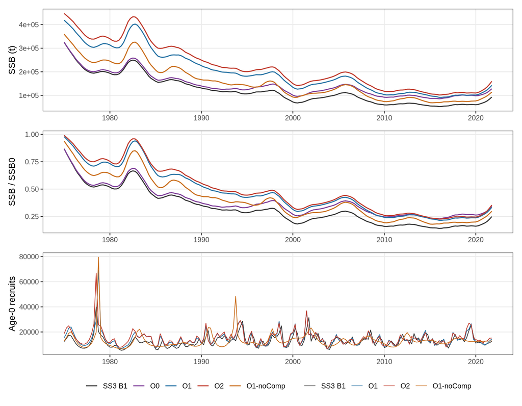

Figure 5: Spawning biomass, depletion and age-0 recruitment: SS3 B1 and the opal fits.

```r
tr = copy(opal_c$trajectory)
tr[, model := factor(model, levels = names(model_col))]
p1 = ggplot(tr, aes(year, ssb, colour = model)) + geom_line(linewidth = 0.6) +
    scale_colour_manual(values = model_col) + labs(x = NULL, y = "SSB (t)", colour = NULL)
p2 = ggplot(tr, aes(year, depletion, colour = model)) + geom_line(linewidth = 0.6) +
    scale_colour_manual(values = model_col) + labs(x = NULL, y = "SSB / SSB0", colour = NULL)
p3 = ggplot(tr[model != "O0"], aes(year, recruits, colour = model)) + geom_line(linewidth = 0.4) +
    scale_colour_manual(values = model_col) + labs(x = NULL, y = "Age-0 recruits", colour = NULL)
(p1 / p2 / p3) + plot_layout(guides = "collect") & theme(legend.position = "bottom")
```

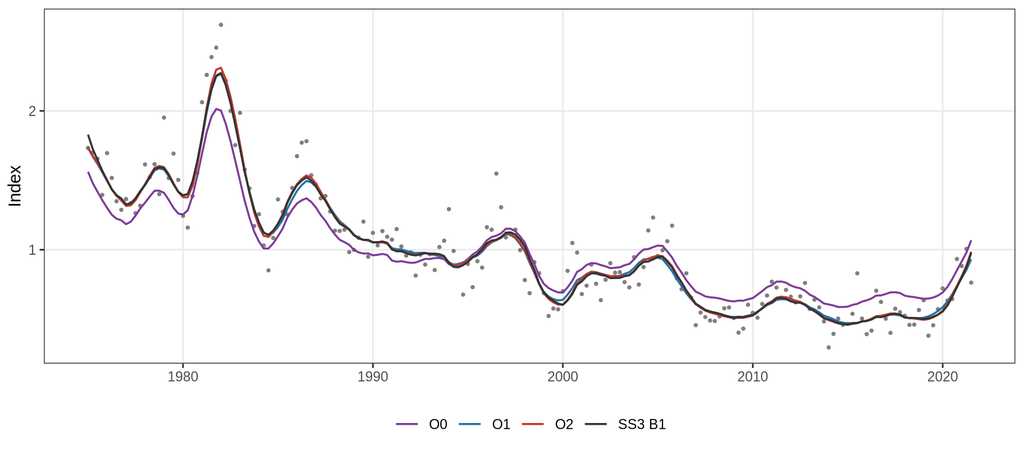

Figure 6: Fits to the longline index (observed: points).

```r
cp = copy(opal_c$cpue)
ggplot(cp, aes(year, pred, colour = model)) +
    geom_point(data = cp[model == "SS3 B1"], aes(year, obs), colour = "grey50", size = 0.6) +
    geom_line(linewidth = 0.6) +
    scale_colour_manual(values = model_col) + labs(x = NULL, y = "Index", colour = NULL)
```

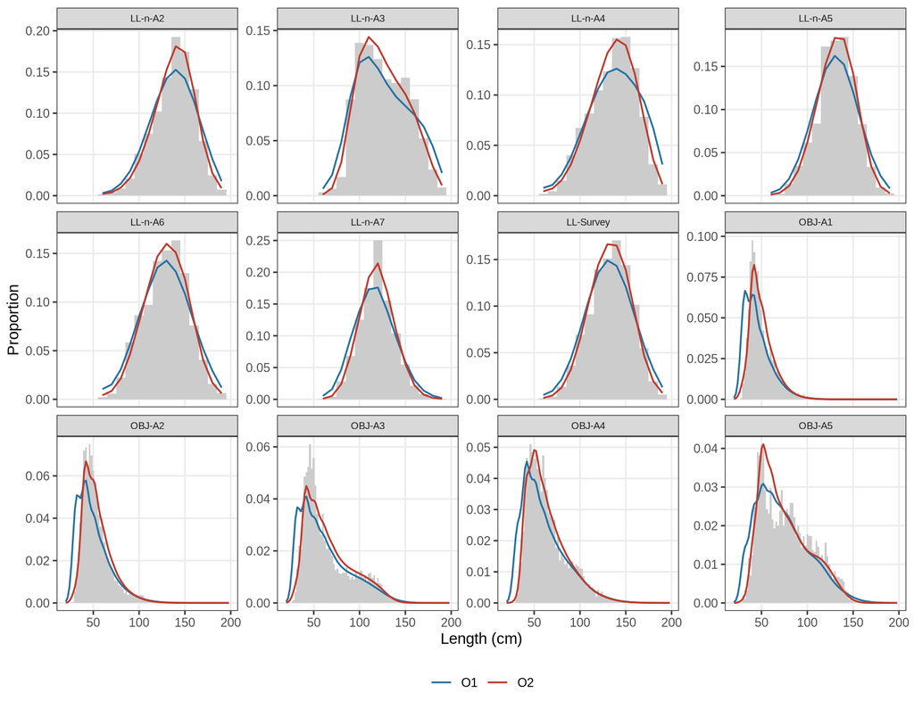

Figure 7: Compositions aggregated over time, by fishery (observed: grey bars): OBJ length compositions (2 cm) and the longline and index size compositions (10 cm).

```r
cc = copy(opal_c$comps)
if (!is.null(cc) && nrow(cc)) {
    cc[, panel := fleets$name[fishery]]
    ggplot(cc, aes(bin, pred, colour = model)) +
        geom_col(data = cc[model == "O1"], aes(bin, obs), inherit.aes = FALSE,
                 fill = "grey80", width = ifelse(cc[model == "O1"]$fishery %in% 15:19, 2, 10)) +
        geom_line(linewidth = 0.6) + facet_wrap(~panel, scales = "free_y", ncol = 4) +
        scale_colour_manual(values = model_col) +
        labs(x = "Length (cm)", y = "Proportion", colour = NULL) +
        theme(strip.text = element_text(size = 7))
}
```

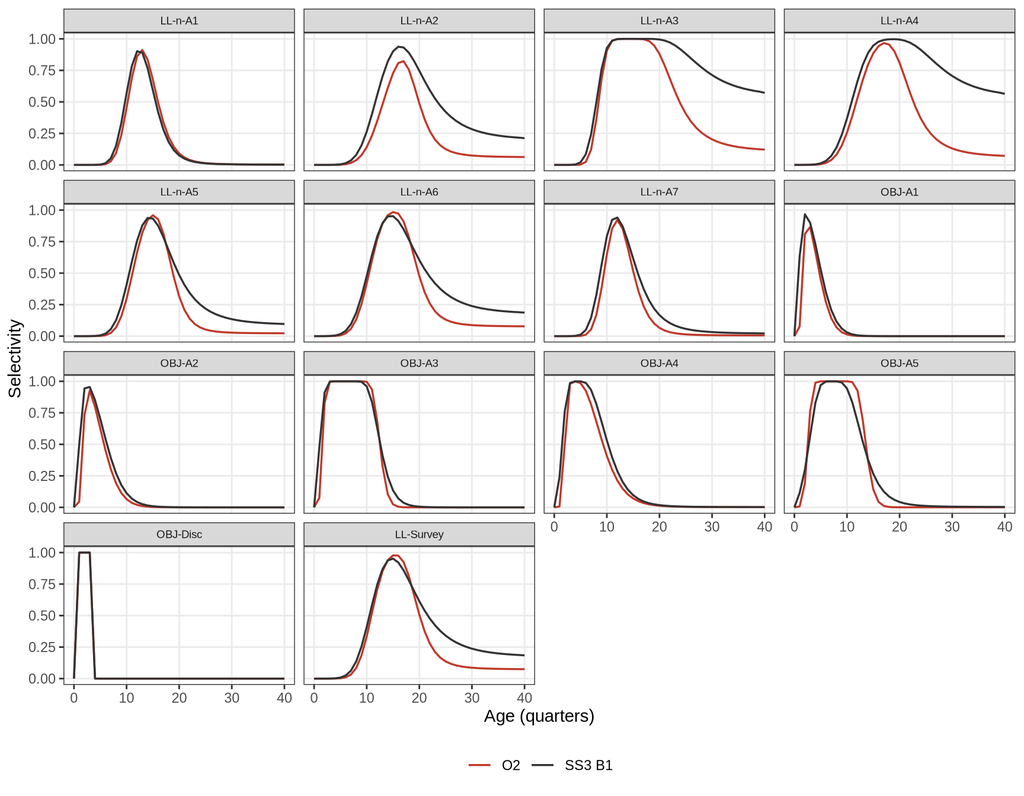

Figure 8: Selectivity-at-age: SS3 B1 and opal O2, by fishery (mirrored fisheries omitted).

```r
sel = copy(opal_c$selectivity)
keep = c(1:7, 15:20, 23)
sel = sel[fishery %in% keep]
sel[, panel := factor(fleets$name[fishery], levels = fleets$name[keep])]
ggplot(sel, aes(age, sel, colour = model)) + geom_line(linewidth = 0.6) +
    facet_wrap(~panel, ncol = 4) +
    scale_colour_manual(values = c("SS3 B1" = "grey20", O2 = "#C0392B")) +
    labs(x = "Age (quarters)", y = "Selectivity", colour = NULL) +
    theme(strip.text = element_text(size = 7))
```

# 6 Limitations and differences from SS3

## 6.1 Not available in opal

- **Within-step catch timing.** opal removes each time step’s catch at its start. How much that matters depends on the mortality within a step (natural and fishing) and on how young the selected fish are, not on the step length alone: it is small when both are low. For this stock, with M of 0.48 per quarter at age 0 and large catches of young fish, it is the largest difference (Table 6). A mid-step removal (Pope) would recover most of it, and SS3’s catch equation nearly all of it.
- **Fishery-specific catch weight-at-age.** opal turns catch in weight into numbers with one weight-at-age vector for every fishery, at one time in the step. SS3 uses each fleet’s catch weight-at-age, which accounts for growth through the step and for size selection within an age. A fishery-by-age catch weight (like the external selectivity matrix) would carry SS3’s exactly.
- **Initial-equilibrium recruitment offset.** SS3’s regime offset scales the initial equilibrium recruitment, unpenalised; opal has no equivalent, so B1 removes it, which moves the whole trajectory (Section 3). opal’s initial deviations (`init_rdev_a`, one per initial age class) could carry B0’s initial numbers-at-age exactly at SS3’s values, but opal penalises them with sigma<sub>R</sub> (about 10 likelihood units for an offset of -0.41 on 41 ages), so a fit would pull the initial state back towards unfished. An unpenalised offset on the initial equilibrium (one parameter in opal’s initial numbers) would let opal be converted from B0 directly.
- **Age selectivity combined with size selectivity.** SS3 multiplies each fleet’s length-based curve by an age curve (pattern 10: 0 at age 0; pattern 11 for the discards); opal has one or the other per fishery.
- **Conditional age-at-length data** (a few records, with lambda 0 in SS3).
- **A complete decomposition of the objective.** With the compositions in the likelihood, opal’s objective is larger than the sum of the weighted terms it reports (by 2,302 units for O1; Table 7), and the difference disappears when the compositions’ lambda is 0, so part of what the composition likelihood contributes is not in the reported `lp_lf`. The NPO blue shark fits show the same. Until it is resolved, the reported terms cannot be added up to the objective, and composition likelihood comparisons between fits rest on the reported `lp_lf` only.

## 6.2 Other structural differences and conversion choices

- **Plus-group length.** SS3 averages the plus group’s length over the ages it accumulates; opal uses the growth curve at the oldest age (0.09 cm).
- **Observation timing.** SS3 predicts the fishery compositions from the catch through the quarter, with mid-quarter lengths, and the index in month 1; opal predicts both from numbers and lengths at the start of the quarter.
- **Generalised size compositions** become opal’s second composition bin scheme, with SS3’s variance adjustments (mult_by_generalized_sizecomp).
- **Catchability.** SS3 solves it analytically (floating q); opal estimates it.
- **Late recruitment deviations.** SS3 estimates deviations for the two quarters after its last main deviation with the same sigma<sub>R</sub> penalty; opal estimates them as ordinary deviations.

# Reproducing this document

| Step | Script | Writes |
| --- | --- | --- |
| 1 | `scripts/01-build-ss3-bridge.r` | the SS3 bridge models and `vignettes/data/epo-bet-ss3-bridge-cache.rds` |
| 2 | `scripts/02-convert-fit-epo-bet-opal.r` | `vignettes/data/epo-bet-opal-cache.rds` and the fitted models |
| 3 | `quarto render vignettes/epo-bet-ss3-to-opal.qmd` | this document |

```r
cat(sprintf("Caches: bridge %s (SS3 %s); opal %s (opal %s, r4ss %s, R %s).\n",
            bridge$made_at, bridge$ss3_version, opal_c$created,
            opal_c$session$opal, opal_c$session$r4ss, opal_c$session$r))
```

```
Caches: bridge 2026-10-30 22:01:13 UTC (SS3 3.30.22.1); opal 2026-10-30 22:12:47 UTC (opal 0.1.2, r4ss 1.56.0, R 4.5.3).
```

# References

IATTC. 2023. *Exploratory Stock Assessment of Bigeye Tuna in the Eastern Pacific Ocean*. Document prepared for the 14th Meeting of the Scientific Advisory Committee (SAC-14). Inter-American Tropical Tuna Commission.

Maunder, Mark N., Richard B. Deriso, Kurt M. Schaefer, et al. 2018. “The Growth Cessation Model: A Growth Model for Species Showing a Near Cessation in Growth with Application to Bigeye Tuna (Thunnus obesus).” *Marine Biology* 165: 76. https://doi.org/10.1007/s00227-018-3336-9.

Methot, Richard D., and Chantell R. Wetzel. 2013. “Stock Synthesis: A Biological and Statistical Framework for Fish Stock Assessment and Fishery Management.” *Fisheries Research* 142: 86–99. https://doi.org/10.1016/j.fishres.2012.10.012.